# 02 Cohort Analysis

## Core microbiome heatmap

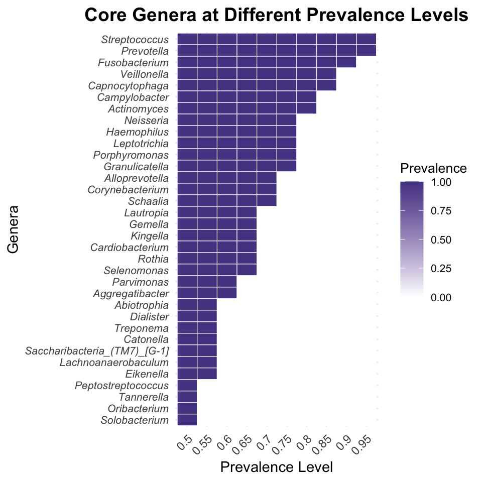

```r
# Get the total list of species
genus_list <- taxa_names(core_ps_genus)

# Initialize an empty list to store core genera at each prevalence level
core_genus_list <- list()

# Loop through prevalence values
for (p in seq(0.5, 1, by = 0.05)) {
  core.taxa <- core_members(core_ps_genus, detection = 1, prevalence = p)
  core_genus_list[[as.character(p)]] <- core.taxa
}

# Create a binary matrix indicating the presence (1) or absence (0) of genera in the core microbiome
core_matrix <- matrix(0, nrow = length(genus_list), ncol = length(core_genus_list),
                      dimnames = list(genus_list, names(core_genus_list)))

for (p in names(core_genus_list)) {
  core_matrix[core_genus_list[[p]], p] <- 1
}

# Remove rows and columns that sum to zero
core_matrix <- core_matrix[rowSums(core_matrix) > 0, colSums(core_matrix) > 0]

# Replace OTU names with genus names in the tax_table
tax_table_genus <- as.data.frame(tax_table(core_ps_genus))
genus_names <- tax_table_genus[rownames(core_matrix), "Genus"]

# Create a new matrix with genus names as rownames
core_matrix_genus <- core_matrix
genus_names <- gsub("g__", "", genus_names)

rownames(core_matrix_genus) <- genus_names


# Sort the matrix by row sums
row_sums <- rowSums(core_matrix_genus)
core_matrix_genus <- core_matrix_genus[order(row_sums, decreasing = TRUE), ]


# Convert the data frame to row-wise format while keeping row names
core_df_genus <- core_matrix_genus %>% as.data.frame() %>% rownames_to_column(var="Genera") %>%
  rowwise() %>%
  mutate(row_total = sum(c_across(starts_with("0.")))) %>%
  arrange(dplyr::desc(row_total)) %>%
  ungroup() %>%
  mutate(Genera = factor(Genera, levels = unique(Genera))) %>%
  dplyr::select(-row_total) %>%
  pivot_longer(cols = -Genera,
               names_to = "prevalence",
               values_to = "value")

# Pivoting the data longer and plotting
plot <- ggplot(core_df_genus, aes(x = prevalence, y = Genera, fill = value)) +
  geom_tile(color = "white") +
  scale_fill_gradient(low = "white", high = "#564592", name = "Prevalence") +
  labs(title = "Core Genera at Different Prevalence Levels",
       x = "Prevalence Level",
       y = "Genera") +
  theme_minimal() +
    scale_y_discrete(limits = rev) +  # <-- flip y-axis order
  theme(
    axis.text.x = element_text(angle = 45, hjust = 1),
    axis.text.y = element_text(size = 8, face = "italic"),  # <-- italic here
    plot.title = element_text(hjust = 0.5, size = 14, face = "bold"),
    legend.position = "right",
    legend.title = element_text(size = 10),
    legend.text = element_text(size = 8)
  )

plot
```

```r
# Plot with reversed y-axis (so highest prevalence at top)
plot <- ggplot(core_df_genus, aes(x = prevalence, y = Genera, fill = value)) +
  geom_tile(color = "white") +
  scale_fill_gradient(low = "white", high = "dodgerblue2", name = "Prevalence") +
  labs(title = "Core Genera at Different Prevalence Levels",
       x = "Prevalence Level",
       y = "Genera") +
  scale_y_discrete(limits = rev(levels(core_df_genus$Genera))) +  # flip order
  theme_minimal() +
  theme(
    axis.text.x = element_text(angle = 45, hjust = 1),
    axis.text.y = element_text(size = 8, face = "italic"),
    plot.title = element_text(hjust = 0.5, size = 14, face = "bold"),
    legend.position = "right",
    legend.title = element_text(size = 10),
    legend.text = element_text(size = 8)
  )
```

# 9.0 Topic modeling: Genus

## Iterate through scaling factors and topic numbers to choose the ideal combination

```r
iterate_res <- iterate_scaling_factors(ps_fs,
                        "Genus",
                        scale_factors = c(10, 100, 1000, 10000),
                        k_values= c(2, 3, 4, 5, 6),
                        auto_chose_k = FALSE,
                        type_column = "Type",
                        method = "Gibbs")

iterate_res$results %>%
  mutate(
    sil_sum = sil_median_Abscess + sil_median_Plaque,
    sil_rank = min_rank(dplyr::desc(sil_sum))) %>% # Rank from highest to lowest
    arrange(sil_rank) %>% kable()
```

## Prep and scale input

```r
results_scaling_genus <- prep_data_scale(ps_fs, "Genus", 1000, "Type")
```

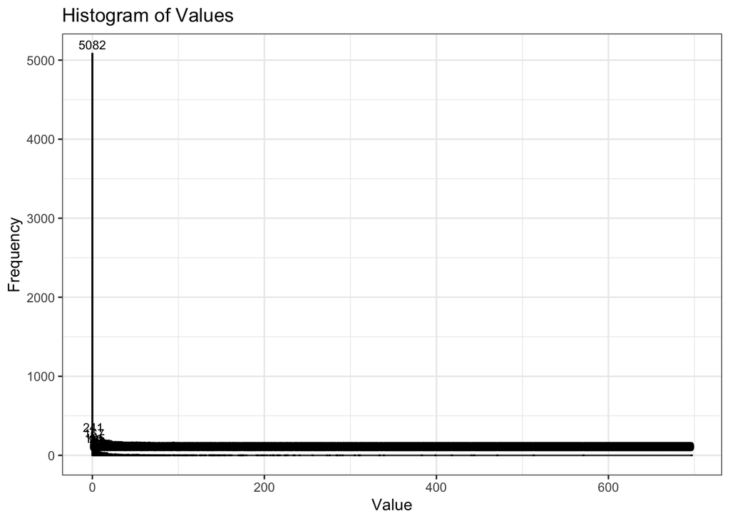

```r
meta_data <- results_scaling_genus$meta_data
counts_data_genus <- results_scaling_genus$counts_data
```

## Fig S5B: Use FindTopicsNumber()

Note: There is no alpha value here

```r
topics <- seq(from = 2, to = 10, by = 1)
res_genus <- RunFindTopicsNumber(counts_data_genus, topics, "Gibbs")
```

```
## fit models... done.
## calculate metrics:
##   Griffiths2004... done.
##   CaoJuan2009... done.
##   Arun2010... done.
##   Deveaud2014... done.
```

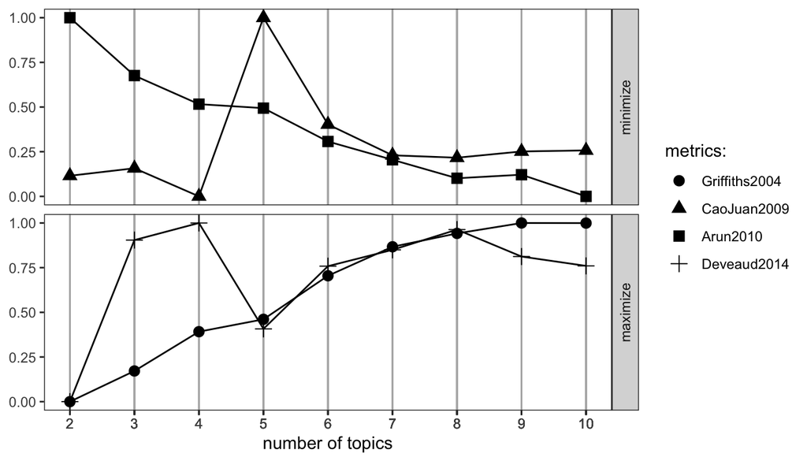

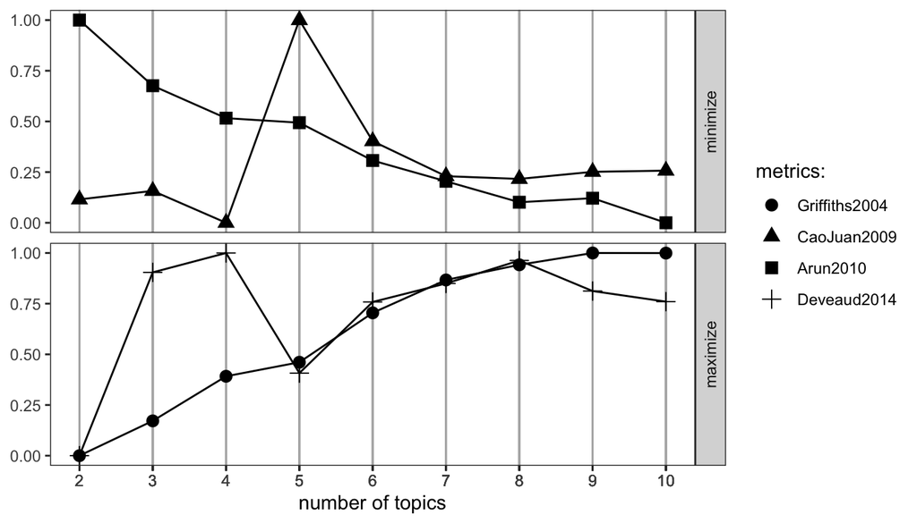

```
## Best number of topics (overall balance): k_8
```

```r
metric_plot_genus <- res_genus$plot +
  geom_vline(xintercept = 7, linetype = "dashed", linewidth = 0.8, color = "red") +
  theme_bw(base_size=13) +
  theme(
  axis.text.x = element_text(size=13, color="black"),
  strip.background = element_rect(fill = "white", color = "black"),
  strip.text = element_text(size = 14, face = "bold"),
  panel.grid.major = element_blank(),
  panel.grid.minor = element_blank()) +
 labs(title = "Genus Level Metrics") +
  theme(
    plot.title = element_text(size = 18, face = "bold", hjust = 0.5)
  )



ggsave("output/FigS5_Topic_Model_FindTopicsNumber_Genus.png", metric_plot_genus, width = 6, height = 4, dpi=600)

res_genus$metrics_df
```

```
## # A tibble: 9 × 2
##   k     combined_score
##   <chr>          <dbl>
## 1 k_8            0.897
## 2 k_10           0.876
## 3 k_9            0.860
## 4 k_7            0.820
## 5 k_4            0.719
## 6 k_6            0.688
## 7 k_3            0.561
## 8 k_5            0.344
## 9 k_2            0.221
```

## LDA: Create the model

You can use the info from the optimum topic numbers printed out in the above function, or adjust as needed.

```r
result_genus <- create_topic_model(counts_data_genus, 7, TRUE, "Gibbs")
```

```
## [1] "Perplexity is: 18.09557688089"
## [1] "Alpha value is: 7.14285714285714"
```

```r
model_genus <- result_genus$lda_model_genus
```

## Fig S8A: Membership of topic by Type

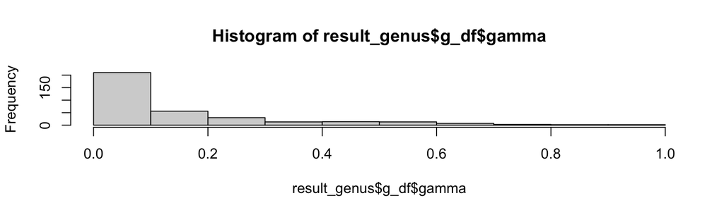

```r
topic_membership_res_genus <- topic_membership(result_genus, "Type", colors_all, result_genus$g_df)

hist(result_genus$g_df$gamma)
```

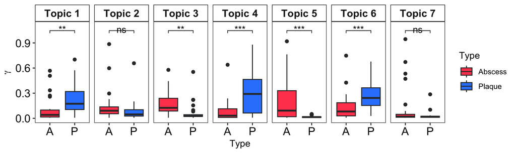

```r
plot_genus <- topic_membership_res_genus$plot +
  stat_compare_means(
    comparisons = list(c("Abscess", "Plaque")),
    method = "wilcox.test",
    label.y = c(1),
    vjust = .45,
    label = "p.signif")+
    ylim(0, 1.1)

plot_genus <- plot_genus + scale_x_discrete(labels = c("Abscess" = "A", "Plaque" = "P")) +
  theme (
    axis.text=element_text(size=13, color="black"),
  )

plot_genus
```

```r
ggsave("output/FigS8_Topic_Model_Topic_Membership_by_Type_Genus.png", plot_genus, width = 8.4, height = 2.5, dpi=600)
```

## Fig S8C: Plot beta

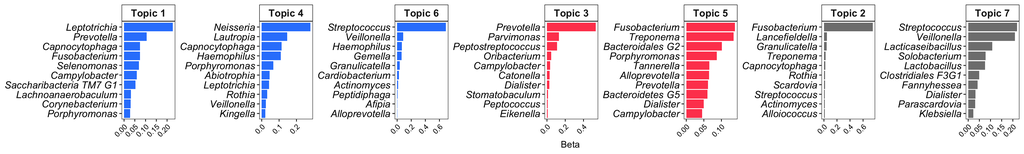

```r
### Plot beta
#plot_beta(result, 15)
#Plot beta, or the numbers that are assigned to each word in a topic. If the beta score is higher, the word matters more in that topic.
result_genus$b_df$topic <- factor(result_genus$b_df$topic, levels = c("1", "4", "6", "3", "5", "2", "7"))


my_colors <- c("1" = "#3185FC", "4" = "#3185FC","6" = "#3185FC","3" = "#FF495C", "5" = "#FF495C")
p_genus <- plot_beta(result_genus, 10, result_genus$b_df,  fill_colors = my_colors)
p_genus
```

```r
ggsave("output/FigS8_Topic_Model_Beta_Barplots_Genus.png", p_genus, width = 20, height = 3, dpi=600)
```

## Fig S8B: Heatmap of gamma scores

```r
heatmap_gamma_genus <- heatmap_gamma(result_genus, "Type", result_genus$g_df)
png("output/Topic_Model_Gamma_Heatmap_Genus.png",
    width = 9, height = 2, units = "in", res = 600)

draw_heatmap(heatmap_gamma_genus)  # <- explicitly use this one

dev.off()
```

## UMAP of gamma scores

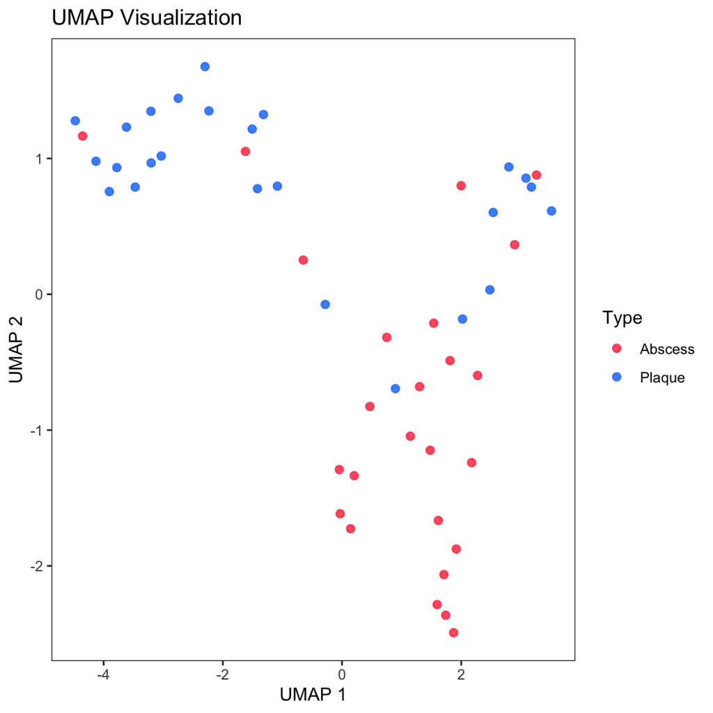

```r
UMAP_res_genus <- plot_gamma_umap(results_genus, "Type", colors_all, result_genus$g_df)
UMAP_res_genus$umap
```

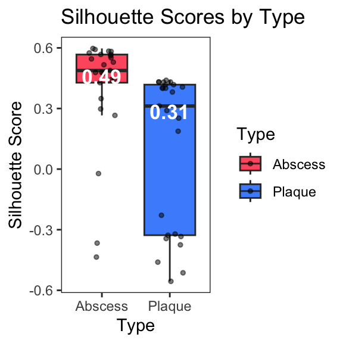

```r
UMAP_res_genus$sil_plot
```

## Fig S9: Relab heatmaps by topic

```r
topic1_res_genus <- heatmap_by_topic(result_genus$b_df, ps_fs_genus_csv, n_top = 10, topic_no = 1)

png("output/FigS9_Topic_Model_RelAb_Heatmap_Topic1_genus.png",
    width = 6.5, height = 2.5, units = "in", res = 600)

draw_heatmap(topic1_res_genus$heatmap)

dev.off()
```

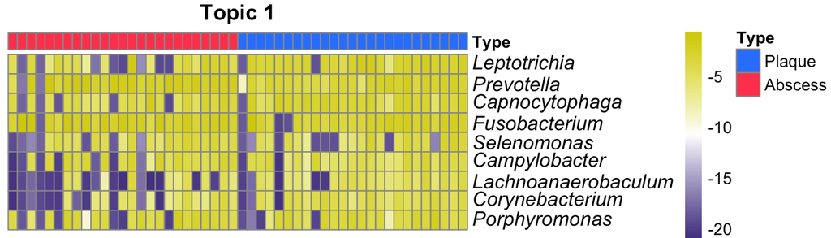

```r
draw_heatmap(topic1_res_genus$heatmap)
```

```r
topic2_res_genus <- heatmap_by_topic(result_genus$b_df, ps_fs_genus_csv, n_top = 10, topic_no = 2)

png("output/FigS9_Topic_Model_RelAb_Heatmap_Topic2_genus.png",
    width = 6.5, height = 2.5, units = "in", res = 600)

draw_heatmap(topic2_res_genus$heatmap)  # <- explicitly use this one

dev.off()
```

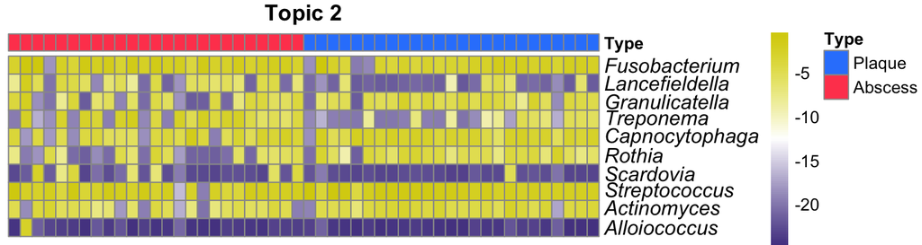

```r
draw_heatmap(topic2_res_genus$heatmap)
```

```r
topic3_res_genus <- heatmap_by_topic(result_genus$b_df, ps_fs_genus_csv, n_top = 10, topic_no = 3)

png("output/FigS9_Topic_Model_RelAb_Heatmap_Topic3_genus.png",
    width = 6.5, height = 2.5, units = "in", res = 600)

draw_heatmap(topic3_res_genus$heatmap)  # <- explicitly use this one

dev.off()
```

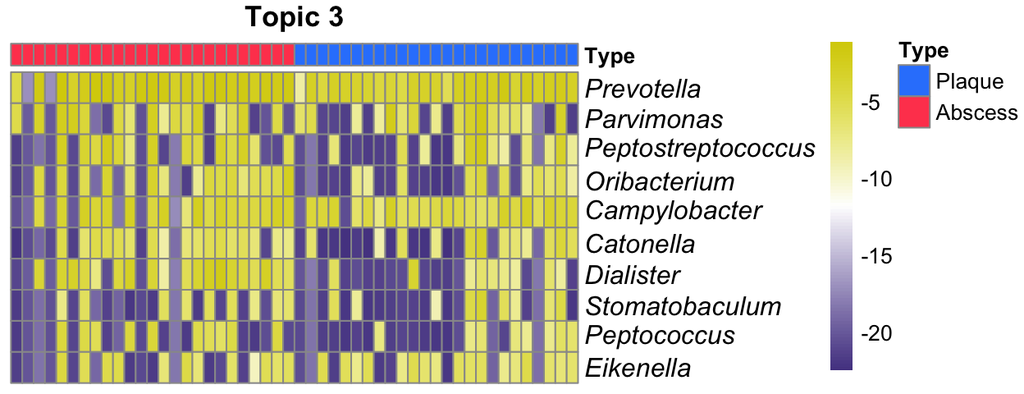

```r
draw_heatmap(topic3_res_genus$heatmap)
```

```r
topic4_res_genus <- heatmap_by_topic(result_genus$b_df, ps_fs_genus_csv, n_top = 10, topic_no = 4)

png("output/FigS9_Topic_Model_RelAb_Heatmap_Topic4_genus.png",
    width = 6.5, height = 2.5, units = "in", res = 600)

draw_heatmap(topic4_res_genus$heatmap)  # <- explicitly use this one

dev.off()
```

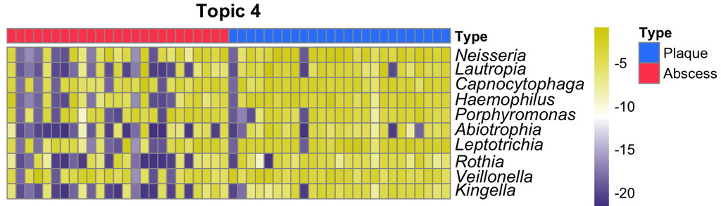

```r
draw_heatmap(topic4_res_genus$heatmap)
```

```r
topic5_res_genus <- heatmap_by_topic(result_genus$b_df, ps_fs_genus_csv, n_top = 10, topic_no = 5)


png("output/FigS9_Topic_Model_RelAb_Heatmap_Topic5_genus.png",
    width = 6.5, height = 2.5, units = "in", res = 600)

draw_heatmap(topic5_res_genus$heatmap)

dev.off()
```

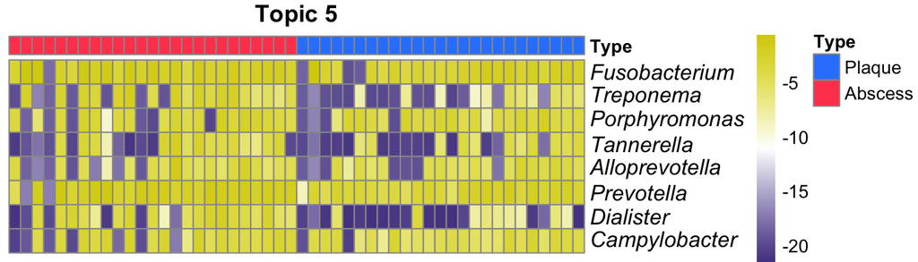

```r
draw_heatmap(topic5_res_genus$heatmap)
```

```r
topic6_res_genus <- heatmap_by_topic(result_genus$b_df, ps_fs_genus_csv, n_top = 10, topic_no = 6)


png("output/FigS9_Topic_Model_RelAb_Heatmap_Topic6_genus.png",
    width = 6.5, height = 2.5, units = "in", res = 600)

draw_heatmap(topic6_res_genus$heatmap)

dev.off()
```

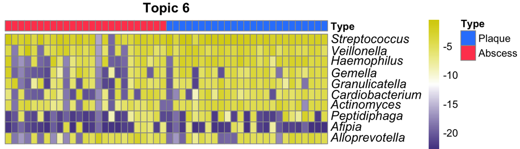

```r
draw_heatmap(topic6_res_genus$heatmap)
```

```r
topic7_res_genus <- heatmap_by_topic(result_genus$b_df, ps_fs_genus_csv, n_top = 10, topic_no = 7)


png("output/FigS9_Topic_Model_RelAb_Heatmap_Topic7_genus.png",
    width = 6.5, height = 2.5, units = "in", res = 600)

draw_heatmap(topic7_res_genus$heatmap)

dev.off()
```

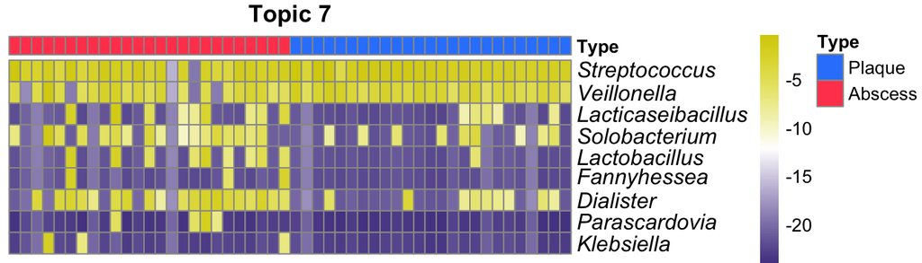

```r
draw_heatmap(topic7_res_genus$heatmap)
```

# 9.0 Topic modeling: Species

## Iterate through scaling factors and topic numbers to choose the ideal combination

```r
iterate_res <- iterate_scaling_factors(ps_fs,
                        "Species",
                        scale_factors = c(10, 100, 1000),
                        k_values= c(2, 3, 4, 5, 6),
                        auto_chose_k = FALSE,
                        type_column = "Type",
                        method = "Gibbs")

iterate_res$results %>%
  mutate(
    sil_sum = sil_median_Abscess + sil_median_Plaque,
    sil_rank = min_rank(dplyr::desc(sil_sum))) %>% # Rank from highest to lowest
    arrange(sil_rank) %>% kable()
```

## Prep and scale input

```r
results_scaling_species <- prep_data_scale(ps_fs, "Species", 1000, "Type")
```

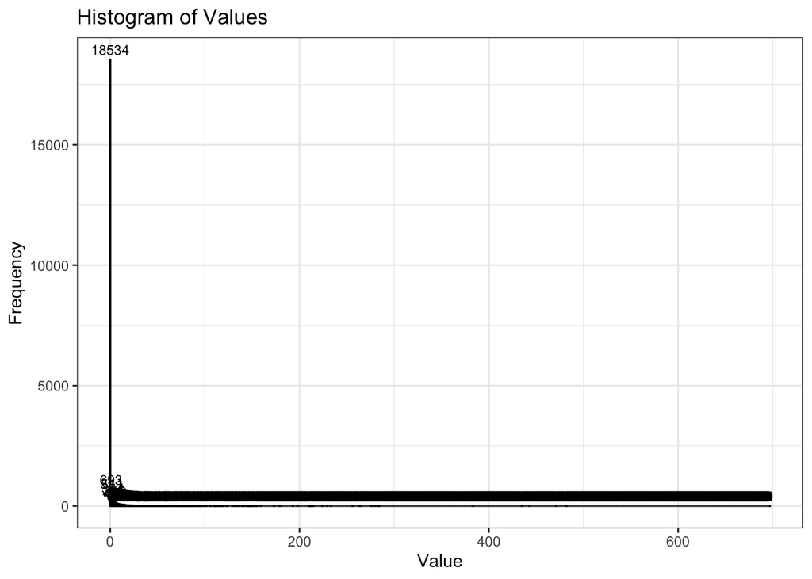

```r
meta_data <- results_scaling_species$meta_data
counts_data_species <- results_scaling_species$counts_data
```

## Fig S5A: Use FindTopicsNumber()

```r
topics <- seq(from = 2, to = 10, by = 1)
res_species <- RunFindTopicsNumber(counts_data_species, topics, "Gibbs")
```

```
## fit models... done.
## calculate metrics:
##   Griffiths2004... done.
##   CaoJuan2009... done.
##   Arun2010... done.
##   Deveaud2014... done.
```

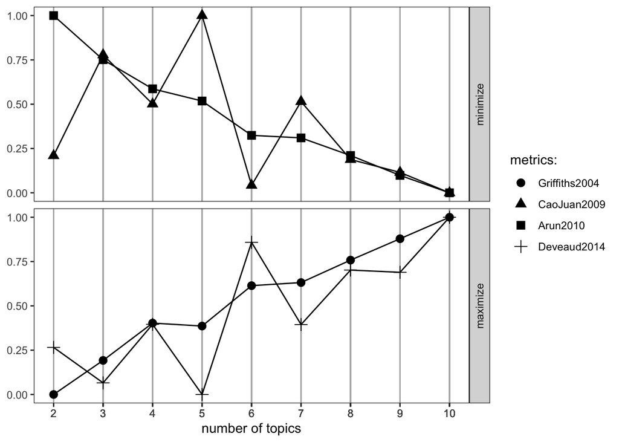

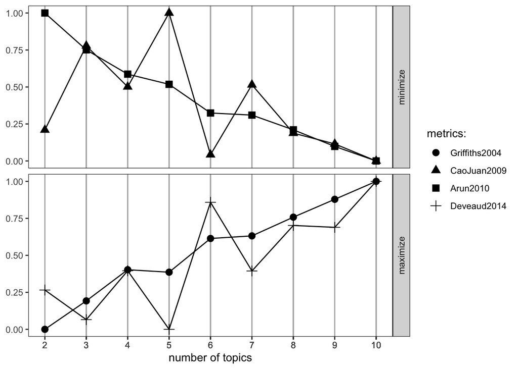

```
## Best number of topics (overall balance): k_10
```

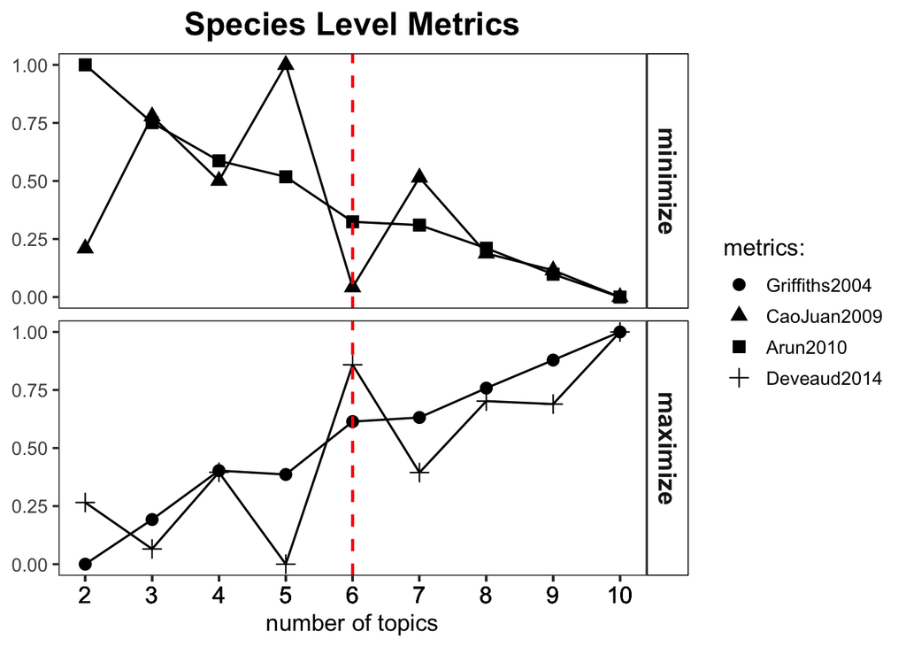

```r
metric_plot_species <- res_species$plot +
  geom_vline(xintercept = 6, linetype = "dashed", linewidth = 0.8, color = "red") +
  theme_bw(base_size=13) +
  theme(
  axis.text.x = element_text(size=13, color="black"),
  strip.background = element_rect(fill = "white", color = "black"),
  strip.text = element_text(size = 14, face = "bold"),
  panel.grid.major = element_blank(),
  panel.grid.minor = element_blank()) +
 labs(title = "Species Level Metrics") +
  theme(
    plot.title = element_text(size = 18, face = "bold", hjust = 0.5)
  )
metric_plot_species
```

```r
ggsave("output/FigS5_Topic_Model_FindTopicsNumber_Species.png", metric_plot_species, width = 6, height = 4, dpi=600)

res_species$metrics_df
```

```
## # A tibble: 9 × 2
##   k     combined_score
##   <chr>          <dbl>
## 1 k_10           1
## 2 k_9            0.839
## 3 k_6            0.776
## 4 k_8            0.765
## 5 k_7            0.550
## 6 k_4            0.428
## 7 k_2            0.264
## 8 k_5            0.217
## 9 k_3            0.182
```

## LDA: Create the model

You can use the info from the optimum topic numbers printed out in the above function, or adjust as needed.

```r
result_species <- create_topic_model(counts_data_species, 6, TRUE, "Gibbs")
```

```
## [1] "Perplexity is: 56.3990092847159"
## [1] "Alpha value is: 8.33333333333333"
```

```r
model_species <- result_species$lda_model
```

## Fig 7C: Membership of topic by Type

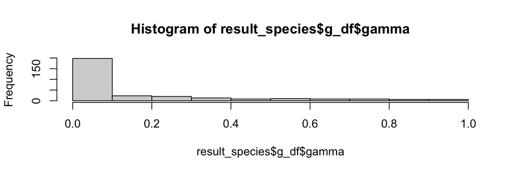

```r
topic_membership_res_species <- topic_membership(result_species, "Type", colors_all, result_species$g_df)

hist(result_species$g_df$gamma)
```

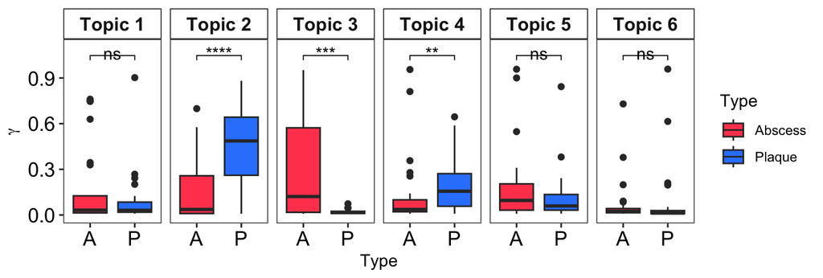

```r
plot_species <- topic_membership_res_species$plot +
  stat_compare_means(
    comparisons = list(c("Abscess", "Plaque")),
    method = "wilcox.test",
    label.y = c(1),
    vjust = .45,
    label = "p.signif")+
    ylim(0, 1.1)

plot_species <- plot_species + scale_x_discrete(labels = c("Abscess" = "A", "Plaque" = "P")) +
  theme (
    axis.text=element_text(size=13, color="black"),
  )
plot_species
```

```r
ggsave("output/Fig7_Topic_Model_Topic_Membership_by_Type_Species.png", plot_species, width = 7.4, height = 2.5, dpi=600)
```

## Fig 7E: Plot beta

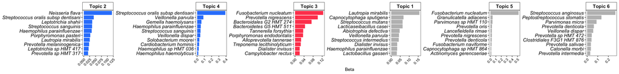

```r
### Plot beta
#Plot beta, or the numbers that are assigned to each word in a topic. If the beta score is higher, the word matters more in that topic.
my_colors <- c("1" = "grey", "2" = "#3185FC", "3" = "#FF495C", "4"= "#3185FC", "5" = "grey", "6" = "grey")


result_species$b_df$topic <- factor(result_species$b_df$topic, levels = c("2", "4", "3", "1", "5", "6"))

p <- plot_beta(result_species, 10, result_species$b_df,  fill_colors = my_colors)
p
```

```r
ggsave("output/Fig7-FigS7_Topic_Model_Beta_Barplots_Species.png", p, width = 25, height = 3, dpi=600)
```

## Fig 7B: Heatmap of gamma scores

```r
heatmap_gamma_species <- heatmap_gamma(result_species, "Type", result_species$g_df)

png("output/Fig7_Topic_Model_Gamma_Heatmap_Species.png",
    width = 9, height = 2.3, units = "in", res = 600)

draw_heatmap(heatmap_gamma_species)  # <- explicitly use this one

dev.off()
```

## Fig 7D: UMAP of gamma scores

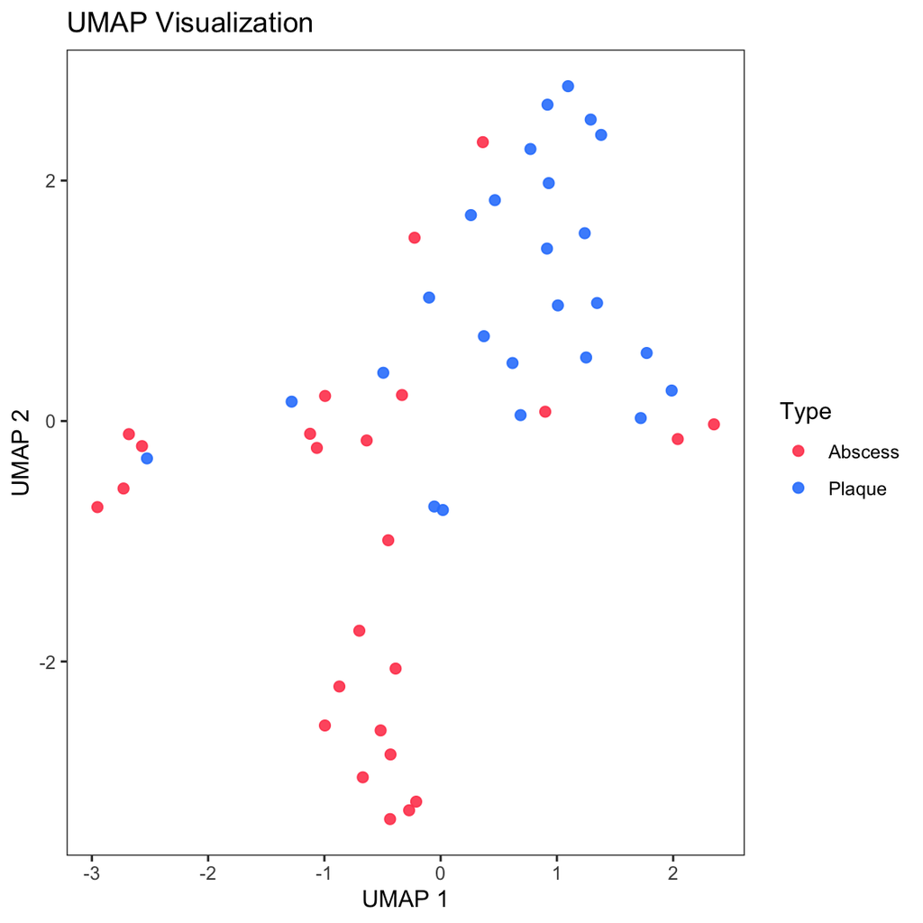

```r
UMAP_res_sp <- plot_gamma_umap(result_species, "Type", colors_all, result_species$g_df)
UMAP_res_sp$umap
```

```r
ggsave("output/Fig7_Topic_Model_Gamma_UMAP_Species.png", UMAP_res_sp$umap, width = 5, height = 4, dpi=600)
```

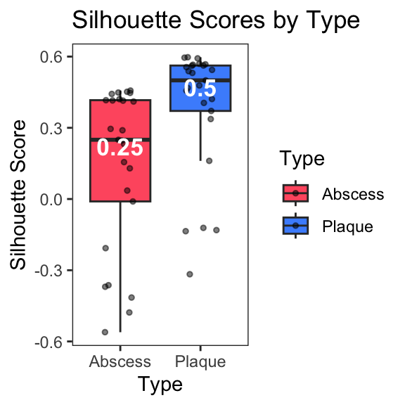

```r
UMAP_res_sp$sil_plot
```

## Fig S6, S7: Relab heatmaps by topic

```r
topic1_res_species <- heatmap_by_topic(result_species$b_df, ps_fs_species_csv, n_top = 10, topic_no = 1)

png("output/FigS6_Topic_Model_RelAb_Heatmap_Topic1_Species.png",
    width = 6.5, height = 2.5, units = "in", res = 600)

draw_heatmap(topic1_res_species$heatmap)

dev.off()
```

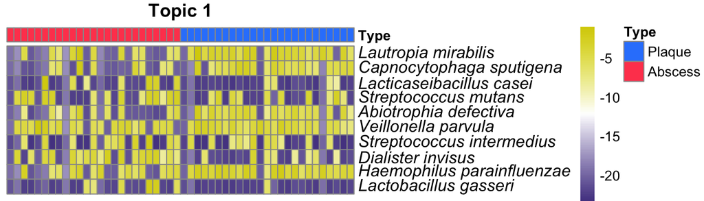

```r
draw_heatmap(topic1_res_species$heatmap)
```

```r
topic2_res_species <- heatmap_by_topic(result_species$b_df, ps_fs_species_csv, n_top = 12, topic_no = 2)

png("output/FigS6_Topic_Model_RelAb_Heatmap_Topic2_Species.png",
    width = 6.5, height = 2.5, units = "in", res = 600)

draw_heatmap(topic2_res_species$heatmap)  # <- explicitly use this one

dev.off()
```

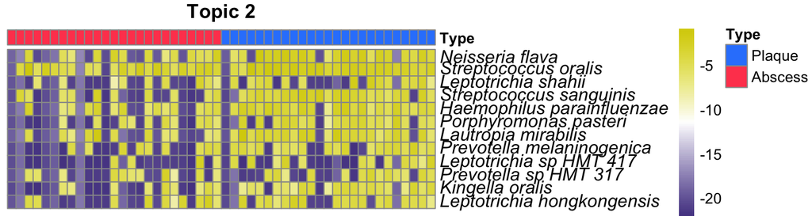

```r
draw_heatmap(topic2_res_species$heatmap)
```

```r
topic3_res_species <- heatmap_by_topic(result_species$b_df, ps_fs_species_csv, n_top = 12, topic_no = 3)

png("output/FigS6_Topic_Model_RelAb_Heatmap_Topic3_Species.png",
    width = 6.5, height = 2.5, units = "in", res = 600)

draw_heatmap(topic3_res_species$heatmap)  # <- explicitly use this one

dev.off()
```

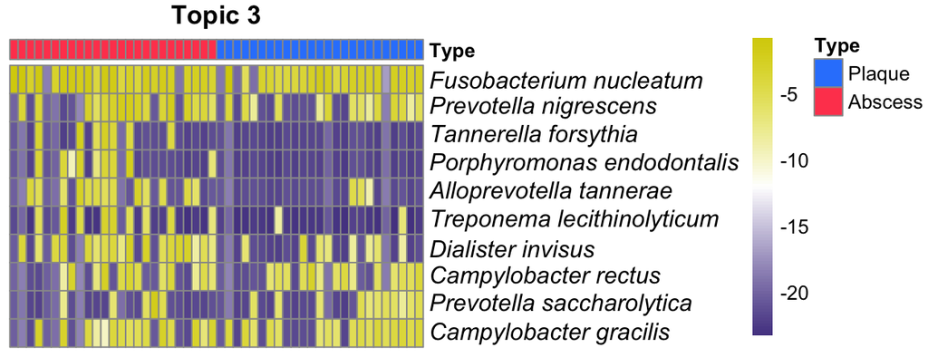

```r
draw_heatmap(topic3_res_species$heatmap)
```

```r
topic4_res_species <- heatmap_by_topic(result_species$b_df, ps_fs_species_csv, n_top = 10, topic_no = 4)

png("output/FigS6_Topic_Model_RelAb_Heatmap_Topic4_Species.png",
    width = 6.5, height = 2.5, units = "in", res = 600)

draw_heatmap(topic4_res_species$heatmap)  # <- explicitly use this one

dev.off()
```

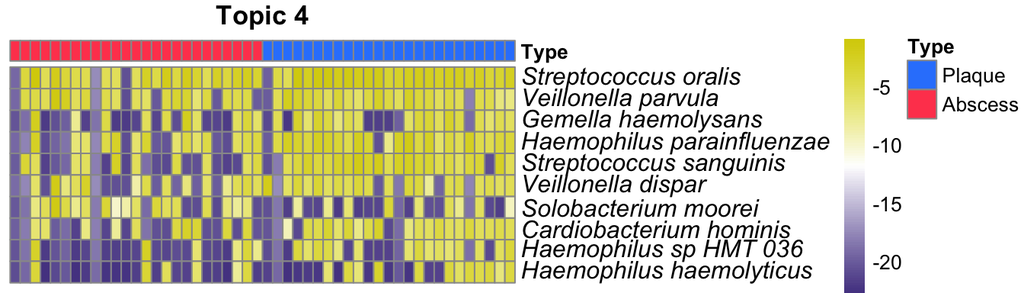

```r
draw_heatmap(topic4_res_species$heatmap)
```

```r
topic5_res_species <- heatmap_by_topic(result_species$b_df, ps_fs_species_csv, n_top = 10, topic_no = 5)


png("output/FigS6_Topic_Model_RelAb_Heatmap_Topic5_Species.png",
    width = 6.5, height = 2.5, units = "in", res = 600)

draw_heatmap(topic5_res_species$heatmap)

dev.off()
```

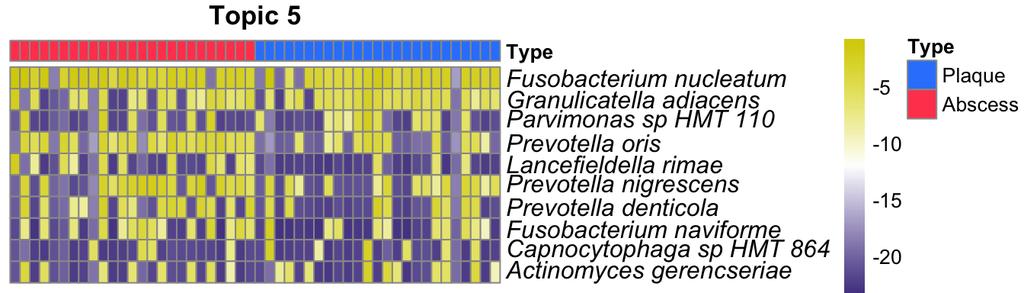

```r
draw_heatmap(topic5_res_species$heatmap)
```

```r
topic6_res_species <- heatmap_by_topic(result_species$b_df, ps_fs_species_csv, n_top = 10, topic_no = 6)


png("output/FigS6_Topic_Model_RelAb_Heatmap_Topic6_Species.png",
    width = 6.5, height = 2.5, units = "in", res = 600)

draw_heatmap(topic6_res_species$heatmap)

dev.off()
```

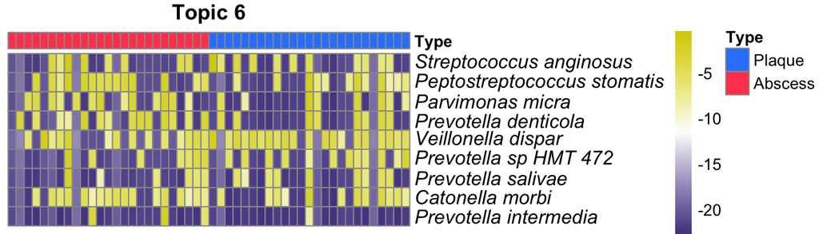

```r
draw_heatmap(topic6_res_species$heatmap)
```